# tree toy

2024-02-18

## Packages

```r
#ioslides_presentation:
require(dplyr)
require(ggplot2)
require(rpart)
require(rpart.plot)
```

## Basic

We have a sample of ten events:

```r
event <-  c(1, 1, 1, 1, 0, 1, 1, 0, 0, 0)
event
```

```
##  [1] 1 1 1 1 0 1 1 0 0 0
```

We wish to classify the whole sample as either `zero` or `one`.

As the majority of the set is made by events of type `one`, we classify the whole sample as a sample of *class* `one`.

The *Miss Classification Error* (MCE) being:

```r
4/10
```

```
## [1] 0.4
```

as four observations, four zeros, are wrongly classified

## Data

In a more coplicated scenario we can have events associated males of females

```r
data <- tibble(
    gender = rep(c('M', 'F'), each = 5),
    event = c(1, 1, 1, 1, 0, 1, 1, 0, 0, 0)

)
data
```

```
## # A tibble: 10 × 2
##    gender event
##    <chr>  <dbl>
##  1 M          1
##  2 M          1
##  3 M          1
##  4 M          1
##  5 M          0
##  6 F          1
##  7 F          1
##  8 F          0
##  9 F          0
## 10 F          0
```

## Root classification

```r
data  |>
    group_by(event)  |>
    count()
```

```
## # A tibble: 2 × 2
## # Groups:   event [2]
##   event     n
##   <dbl> <int>
## 1     0     4
## 2     1     6
```

As in the root node `one` is the most frequent class, we classify the whole node as a node of class `one`

The miss classification error (MCE), where zero occurs, is therefore:

```r
e0 <- 4/10
e0
```

```
## [1] 0.4
```

## First split

We now split our data based on variable `gender`

```r
split_gender <- data  |>
    group_by(gender, event)  |>
    summarise(n = n(), .groups = 'drop')
split_gender
```

```
## # A tibble: 4 × 3
##   gender event     n
##   <chr>  <dbl> <int>
## 1 F          0     3
## 2 F          1     2
## 3 M          0     1
## 4 M          1     4
```

## First split

```r
split_gender
```

```
## # A tibble: 4 × 3
##   gender event     n
##   <chr>  <dbl> <int>
## 1 F          0     3
## 2 F          1     2
## 3 M          0     1
## 4 M          1     4
```

The `F` node is at prevalece `zero`. As a result, MCE is:

```r
e1_F <- 2 / (3+2); e1_F
```

```
## [1] 0.4
```

The `M` node is at prevalece `one`. As a result, MCE is:

```r
e1_M <- 1 / (4+1); e1_M
```

```
## [1] 0.2
```

## First split

```r
split_gender
```

```
## # A tibble: 4 × 3
##   gender event     n
##   <chr>  <dbl> <int>
## 1 F          0     3
## 2 F          1     2
## 3 M          0     1
## 4 M          1     4
```

The over all MCE is:

```r
e1 <- (2+1) / (3+2+1+4); e1
```

```
## [1] 0.3
```

## First split

We rember the MCE at root node was

```r
e0
```

```
## [1] 0.4
```

Scaling on `e0`, `r0` becomes:

```r
r0 <- e0/e0
r0
```

```
## [1] 1
```

while `r1` becomes:

```r
r1 <- e1/e0
r1
```

```
## [1] 0.75
```

## toy tree

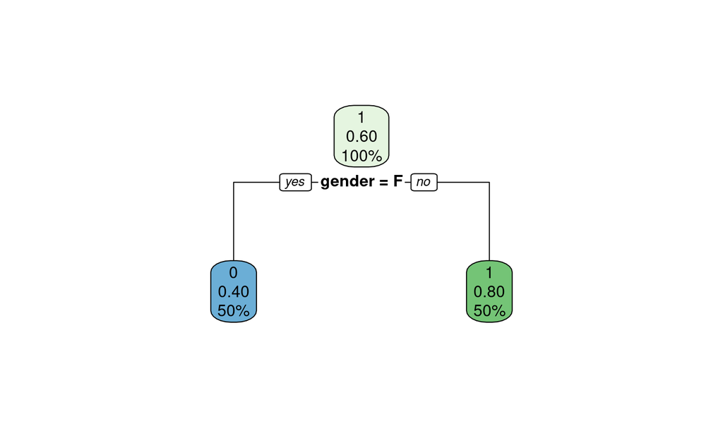

```r
fm <- rpart(event~gender,
    data = data,
    method = 'class',
    parms = list(split = 'gini'),
    control = rpart.control(
        minbucket = 2,
        cp = 0.00001),
    xval = 2)
rpart.plot(fm)
```

## Cost of pruning

```r
printcp(fm)
```

```
##
## Classification tree:
## rpart(formula = event ~ gender, data = data, method = "class",
##     parms = list(split = "gini"), control = rpart.control(minbucket = 2,
##         cp = 1e-05), xval = 2)
##
## Variables actually used in tree construction:
## [1] gender
##
## Root node error: 4/10 = 0.4
##
## n= 10
##
##        CP nsplit rel error xerror   xstd
## 1 0.25000      0      1.00    1.0 0.3873
## 2 0.00001      1      0.75    1.5 0.3873
```

```r
CP <- (1-0.75)/(1-0)
CP
```

```
## [1] 0.25
```